# Personal Activity Forecasting

Archon Financial Management & Investments

27 de septiembre de 2015

## Summary

In this project we are going to predict the manner in which, a sample of individuals who take measurements about themselves regularly to improve their health do their excercises.

Two machine learning algorithms are going to be used: **Decision Trees** and **Random Forest**, the prediction is going to be made with the algorithm with the best performance, understanding performance as the least out of sample expected error.

## Data Preprocessing and analysis

Due to security concerns with the exchange of R code, the code will not be run during the evaluation by your classmates, so we are going to use `echo='false'` and `results='hide'`.

```
## Versión 3.5.0 Copyright (c) 2006-2015 Togaware Pty Ltd.
## Escriba 'rattle()' para agitar, sacudir y  rotar sus datos.
```

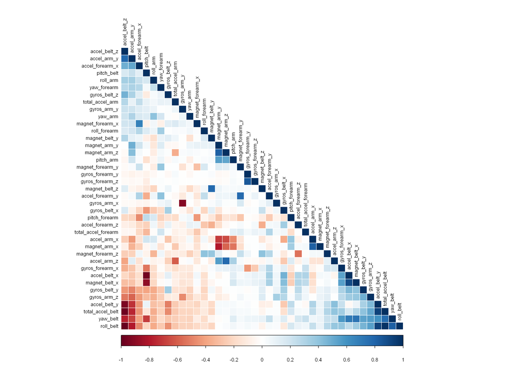

After preprocessing, the new datasets have the next dimensions:

```r
# Training dataset
dim(myTraining)
```

```
## [1] 11776    40
```

```r
# Testing dataset
dim(myTesting)
```

```
## [1] 7846   40
```

## Models creation

Now, we are going to create a **Decision Tree** in order to know their out of sample error rate:

Now we found that with the Decision Tree the **Out of Sample expected error is 30.41%.** This is a summary of the statistics found:

```r
# Confusion Matrix table, Decision Tree
confus_dTree
```

```
## Confusion Matrix and Statistics
##
##           Reference
## Prediction    A    B    C    D    E
##          A 1870  207   77   65   71
##          B   50  813  148   88  156
##          C  111  391 1007  268  268
##          D  183   73  123  858   35
##          E   18   34   13    7  912
##
## Overall Statistics
##
##                Accuracy : 0.6959
##                  95% CI : (0.6856, 0.7061)
##     No Information Rate : 0.2845
##     P-Value [Acc > NIR] : < 2.2e-16
##
##                   Kappa : 0.6155
##  Mcnemar's Test P-Value : < 2.2e-16
##
## Statistics by Class:
##
##                      Class: A Class: B Class: C Class: D Class: E
## Sensitivity            0.8378   0.5356   0.7361   0.6672   0.6325
## Specificity            0.9252   0.9302   0.8398   0.9369   0.9888
## Pos Pred Value         0.8166   0.6478   0.4924   0.6745   0.9268
## Neg Pred Value         0.9348   0.8930   0.9378   0.9349   0.9228
## Prevalence             0.2845   0.1935   0.1744   0.1639   0.1838
## Detection Rate         0.2383   0.1036   0.1283   0.1094   0.1162
## Detection Prevalence   0.2919   0.1600   0.2606   0.1621   0.1254
## Balanced Accuracy      0.8815   0.7329   0.7879   0.8020   0.8106
```

a graphical representation of the decision tree:

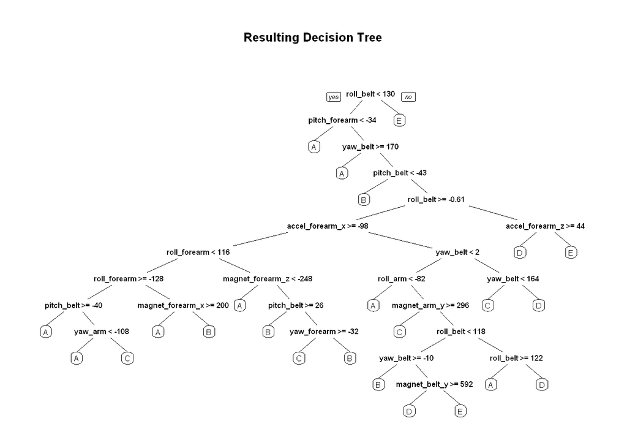

Next, we’ll try to improve it with a **Random Forest** Model.

Now we can see that the Random Forest give us an **Out of Sample expected error is 0.94%** which is much better than the one found with the Decision Tree (30.41%).

This is a summary of the statistics found with the Random Forest:

```r
confus_rForest
```

```
## Confusion Matrix and Statistics
##
##           Reference
## Prediction    A    B    C    D    E
##          A 2223    8    2    0    0
##          B    7 1506   20    0    0
##          C    0    4 1339   17    1
##          D    2    0    7 1265    2
##          E    0    0    0    4 1439
##
## Overall Statistics
##
##                Accuracy : 0.9906
##                  95% CI : (0.9882, 0.9926)
##     No Information Rate : 0.2845
##     P-Value [Acc > NIR] : < 2.2e-16
##
##                   Kappa : 0.9881
##  Mcnemar's Test P-Value : NA
##
## Statistics by Class:
##
##                      Class: A Class: B Class: C Class: D Class: E
## Sensitivity            0.9960   0.9921   0.9788   0.9837   0.9979
## Specificity            0.9982   0.9957   0.9966   0.9983   0.9994
## Pos Pred Value         0.9955   0.9824   0.9838   0.9914   0.9972
## Neg Pred Value         0.9984   0.9981   0.9955   0.9968   0.9995
## Prevalence             0.2845   0.1935   0.1744   0.1639   0.1838
## Detection Rate         0.2833   0.1919   0.1707   0.1612   0.1834
## Detection Prevalence   0.2846   0.1954   0.1735   0.1626   0.1839
## Balanced Accuracy      0.9971   0.9939   0.9877   0.9910   0.9986
```

# Conclusion

We found that the Random Forest brings a better performance than the Decision tree in this specific task, so we utilized it in order to predict the twenty outputs for the homework.